# THE TACTICAL EVOLUTION OF EUROPEAN FOOTBALL (2013-2025)

## A Data-Driven Analysis of Formation Trends Across Europe's Top 5 Leagues

### SUMMARY

This analysis examines how tactical formations have evolved in Europe's elite football leagues from 2013 to 2025, revealing patterns of tactical convergence, geographic uniqueness, and strategic contagion. Through analysis of 21,276 matches across the Premier League, La Liga, Serie A, Bundesliga, and Ligue 1, we uncover how formations rise and fall, which tactics deliver results, and how successful strategies spread across leagues.

Key Findings:

```python
#Import libraries and load data
import pandas as pd
import numpy as np
import matplotlib.pyplot as plt
import seaborn as sns
from scipy.stats import pearsonr, spearmanr, linregress
import warnings
warnings.filterwarnings('ignore')

# Load competitions (for league filtering)
competitions = pd.read_csv('data/competitions.csv')

# Load games
games = pd.read_csv('data/games.csv')

# Load player valuations
player_valuations = pd.read_csv('data/player_valuations.csv')
```

```python
# Filter and clean the data for analysing top 5 leagues in Europe

# Top 5 league IDs
top5_leagues = ['GB1', 'ES1', 'IT1', 'L1', 'FR1']

# Filter games for top 5 leagues
df = games[games['competition_id'].isin(top5_leagues)].copy()

# Remove games without formation data
df = df[df['home_club_formation'].notna() & df['away_club_formation'].notna()].copy()

# Convert dates and extract year
df['date'] = pd.to_datetime(df['date'])
df['year'] = df['date'].dt.year
df['season_year'] = df['season'].astype(int)

# Filter for 2010 onwards
df = df[df['season_year'] >= 2010].copy()
```

## Central Question: How have tactical formations evolved in Europe's elite leagues from 2013-2025, and what drives teams' formation choices?

#### THE LANDSCAPE OF TACTICAL CHANGE

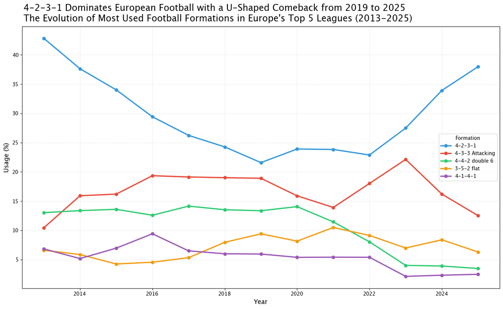

```python
# FORMATION EVOLUTION OVER TIME

# Top 5 formations to track
top_5_formations = ['4-2-3-1', '4-3-3 Attacking', '4-4-2 double 6', '3-5-2 flat', '4-1-4-1']

# Calculate formation usage percentage by year
formation_trends = []

for year in sorted(df['year'].unique()):
    year_df = df[df['year'] == year]
    year_formations = pd.concat([year_df['home_club_formation'],
                                 year_df['away_club_formation']])
    total_formations = len(year_formations)

    for formation in top_5_formations:
        count = (year_formations == formation).sum()
        percentage = 100 * count / total_formations

        formation_trends.append({
            'year': year,
            'formation': formation,
            'percentage': percentage
        })

trends_df = pd.DataFrame(formation_trends)

# Pivot for easier plotting
trends_pivot = trends_df.pivot(index='year', columns='formation', values='percentage')

# Create the visualization
fig, ax = plt.subplots(figsize=(14, 8))

# Plot lines for each formation
colors = {
    '4-2-3-1': '#3498db',
    '4-3-3 Attacking': '#e74c3c',
    '4-4-2 double 6': '#2ecc71',
    '3-5-2 flat': '#f39c12',
    '4-1-4-1': '#9b59b6',
}



for formation in top_5_formations:
    ax.plot(trends_pivot.index, trends_pivot[formation],
           marker='o', linewidth=2.5, label=formation, markersize=6,
           color=colors.get(formation, 'gray'))

# Labels
ax.set_xlabel('Year', fontsize=13, fontweight='bold')
ax.set_ylabel('Usage (%)', fontsize=13, fontweight='bold')
ax.legend(title='Formation', loc='best', fontsize=10)
ax.grid(True, alpha=0.3, linestyle='--')

# Action title at top left
title_text = '4-2-3-1 Dominates European Football with a U-Shaped Comeback from 2019 to 2025\nThe Evolution of Most Used Football Formations in Europe\'s Top 5 Leagues (2013-2025)'
fig.text(0.05, 1.06, title_text,
        ha='left', va='top', fontsize=18, fontweight='bold')

plt.tight_layout()
plt.show()
```

European football has witnessed a remarkable tactical journey over the past 13 years. The 4-2-3-1 formation, which dominated 42.8% of all matches in 2013, experienced a dramatic decline to just 21.9% by 2019—only to stage a powerful comeback, reaching 38% by 2025.

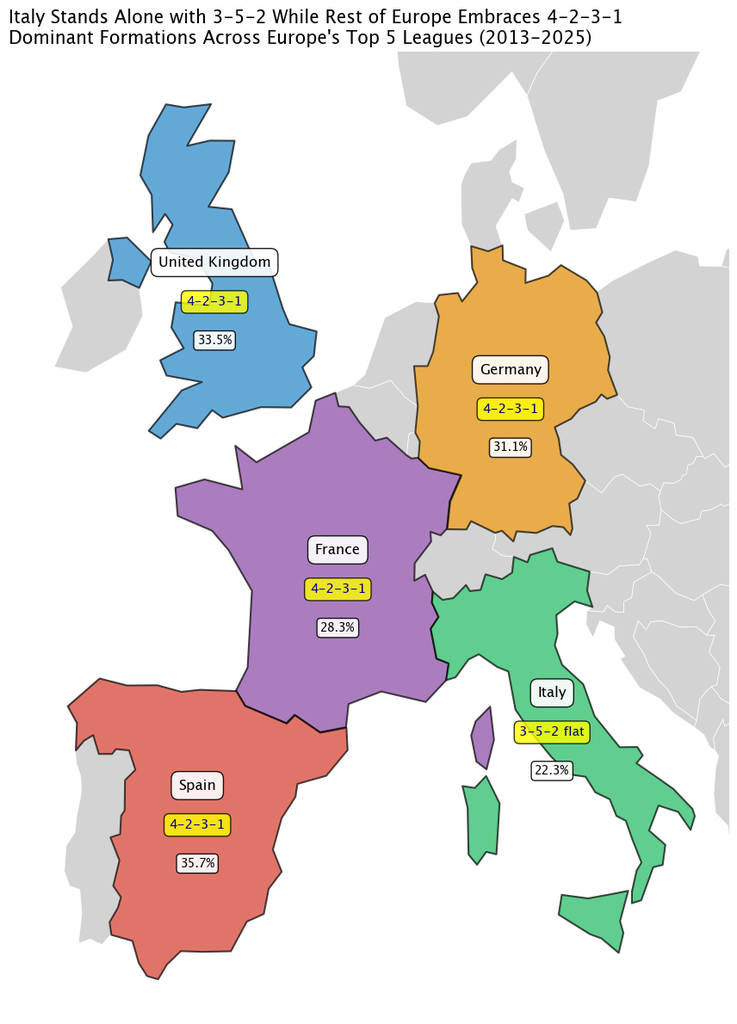

```python
# EUROPE MAP - DOMINANT FORMATIONS

import geopandas as gpd
import warnings
warnings.filterwarnings('ignore')

# Download the data directly from Natural Earth
url = "https://naciscdn.org/naturalearth/110m/cultural/ne_110m_admin_0_countries.zip"

world = gpd.read_file(url)

# Filter for European countries
europe = world[world['CONTINENT'] == 'Europe']

# Our 5 countries
top5_countries = ['United Kingdom', 'Spain', 'Italy', 'Germany', 'France']
top5_map = europe[europe['NAME'].isin(top5_countries)]

# Calculate dominant formation for each league
league_to_country = {
    'GB1': 'United Kingdom',
    'ES1': 'Spain',
    'IT1': 'Italy',
    'L1': 'Germany',
    'FR1': 'France'
}

# Define colors for each country
country_colors = {
    'United Kingdom': '#3498db',
    'Spain': '#e74c3c',
    'Italy': '#2ecc71',
    'Germany': '#f39c12',
    'France': '#9b59b6'
}

league_data = {}
for comp_id, country in league_to_country.items():
    league_df = df[df['competition_id'] == comp_id]  # Changed from df_clean to df
    league_formations = pd.concat([league_df['home_club_formation'],
                                   league_df['away_club_formation']])

    top_formation = league_formations.value_counts().head(1)
    formation = top_formation.index[0]
    percentage = 100 * top_formation.values[0] / len(league_formations)

    league_data[country] = {
        'formation': formation,
        'percentage': percentage
    }

# Create the map
fig, ax = plt.subplots(1, 1, figsize=(16, 12))

# Plot Europe in light gray
europe.plot(ax=ax, color='lightgray', edgecolor='white', linewidth=0.5)

# Plot each of top 5 countries with different colors
for idx, row in top5_map.iterrows():
    country = row['NAME']
    color = country_colors.get(country, 'lightblue')

    single_country = gpd.GeoDataFrame([row], crs=top5_map.crs)
    single_country.plot(ax=ax, color=color, edgecolor='black', linewidth=1.5, alpha=0.7)

# Add formation labels to each country
label_adjustments = {
    'France': (5.5, 4),
    'Spain': (0, 0),
    'Italy': (0, 0),
    'Germany': (0, 0),
    'United Kingdom': (0, 0)
}

for idx, row in top5_map.iterrows():
    country = row['NAME']
    if country in league_data:
        centroid = row['geometry'].centroid
        x_adj, y_adj = label_adjustments.get(country, (0, 0))

        formation = league_data[country]['formation']
        percentage = league_data[country]['percentage']

        # Country name
        ax.text(centroid.x + x_adj, centroid.y + 0.5 + y_adj, country,
               ha='center', fontsize=12, fontweight='bold',
               bbox=dict(boxstyle='round,pad=0.5', facecolor='white', alpha=0.9, edgecolor='black'))

        # Formation
        ax.text(centroid.x + x_adj, centroid.y - 0.5 + y_adj, f'{formation}',
               ha='center', fontsize=11, color='darkblue', fontweight='bold',
               bbox=dict(boxstyle='round,pad=0.4', facecolor='yellow', alpha=0.8, edgecolor='black'))

        # Percentage
        ax.text(centroid.x + x_adj, centroid.y - 1.5 + y_adj, f'{percentage:.1f}%',
               ha='center', fontsize=10, fontweight='bold',
               bbox=dict(boxstyle='round,pad=0.3', facecolor='white', alpha=0.9, edgecolor='black'))

# Set map bounds
ax.set_xlim(-12, 20)
ax.set_ylim(35, 60)
ax.set_axis_off()

# ACTION TITLE
ax.set_title('Italy Stands Alone with 3-5-2 While Rest of Europe Embraces 4-2-3-1\nDominant Formations Across Europe\'s Top 5 Leagues (2013-2025)',
             fontsize=15, fontweight='bold', loc='left')

plt.tight_layout()
plt.show()
```

While 4-2-3-1 dominates four of Europe's top five leagues, Italy stands alone. Serie A's preference for 3-5-2 flat (22.3% usage) represents more than just tactical choice - it's cultural identity.

#### WHAT ACTUALLY WORKS?

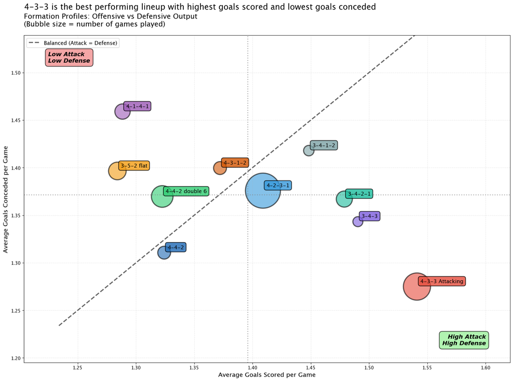

```python
# ATTACK vs DEFENSE SCATTER PLOT

# Calculate offensive and defensive stats for each formation
formation_stats = []

for formation in df['home_club_formation'].value_counts().head(10).index:
    # Home games with this formation
    home_games = df[df['home_club_formation'] == formation]
    away_games = df[df['away_club_formation'] == formation]

    if len(home_games) >= 20 and len(away_games) >= 20:  # Minimum sample size
        # Offensive output (goals scored)
        home_goals_scored = home_games['home_club_goals'].mean()
        away_goals_scored = away_games['away_club_goals'].mean()
        avg_goals_scored = (home_goals_scored + away_goals_scored) / 2

        # Defensive output (goals conceded)
        home_goals_conceded = home_games['away_club_goals'].mean()
        away_goals_conceded = away_games['home_club_goals'].mean()
        avg_goals_conceded = (home_goals_conceded + away_goals_conceded) / 2

        # Store results
        formation_stats.append({
            'Formation': formation,
            'Avg Goals Scored': avg_goals_scored,
            'Avg Goals Conceded': avg_goals_conceded,
            'Games': len(home_games) + len(away_games)
        })

stats_df = pd.DataFrame(formation_stats)

# Define colors for each formation
formation_colors = {
    '4-2-3-1': '#3498db',
    '4-3-3 Attacking': '#e74c3c',
    '4-4-2 double 6': '#2ecc71',
    '3-5-2 flat': '#f39c12',
    '4-1-4-1': '#9b59b6',
    '3-4-2-1': '#1abc9c',
    '3-4-3': "#7c5cde",
    '4-4-2': "#1d68b4",
    '3-4-1-2': "#7ca2a5",
    '4-3-1-2': '#d35400'
}

# Create the scatter plot
fig, ax = plt.subplots(figsize=(16, 12))

# Plot each formation
for _, row in stats_df.iterrows():
    formation = row['Formation']
    color = formation_colors.get(formation, 'gray')

    # Plot point
    ax.scatter(row['Avg Goals Scored'], row['Avg Goals Conceded'],
              s=row['Games']/2, alpha=0.6, color=color,
              edgecolors='black', linewidth=2.5)

    # Add formation label
    ax.annotate(formation,
               (row['Avg Goals Scored'], row['Avg Goals Conceded']),
               xytext=(8, 8), textcoords='offset points',
               fontsize=12, fontweight='bold',
               bbox=dict(boxstyle='round,pad=0.4', facecolor=color,
                        alpha=0.8, edgecolor='black', linewidth=1.5))

# Add diagonal line (balanced attack/defense)
x_range = [stats_df['Avg Goals Scored'].min() - 0.05,
           stats_df['Avg Goals Scored'].max() + 0.05]
ax.plot(x_range, x_range, 'k--', linewidth=2.5, alpha=0.6,
       label='Balanced (Attack = Defense)')

# Add quadrant lines
avg_scored = stats_df['Avg Goals Scored'].mean()
avg_conceded = stats_df['Avg Goals Conceded'].mean()
ax.axvline(avg_scored, color='gray', linestyle=':', linewidth=2, alpha=0.6)
ax.axhline(avg_conceded, color='gray', linestyle=':', linewidth=2, alpha=0.6)

# Set axis limits
x_min = stats_df['Avg Goals Scored'].min() - 0.08
x_max = stats_df['Avg Goals Scored'].max() + 0.08
y_min = stats_df['Avg Goals Conceded'].min() - 0.08
y_max = stats_df['Avg Goals Conceded'].max() + 0.08

ax.set_xlim(x_min, x_max)
ax.set_ylim(y_min, y_max)

# Add labels on the corner
# Top left: Low Attack, Low Defense
ax.text(0.05, 0.95, 'Low Attack\nLow Defense',
       transform=ax.transAxes,
       ha='left', va='top', fontsize=13, fontweight='bold', style='italic',
       bbox=dict(boxstyle='round,pad=0.5', facecolor='lightcoral',
                alpha=0.7, edgecolor='black', linewidth=1.5))

# Bottom right: High Attack, High Defense
ax.text(0.95, 0.05, 'High Attack\nHigh Defense',
       transform=ax.transAxes,
       ha='right', va='bottom', fontsize=13, fontweight='bold', style='italic',
       bbox=dict(boxstyle='round,pad=0.5', facecolor='lightgreen',
                alpha=0.7, edgecolor='black', linewidth=1.5))

# Labels and title
ax.set_xlabel('Average Goals Scored per Game', fontsize=14, fontweight='bold')
ax.set_ylabel('Average Goals Conceded per Game', fontsize=14, fontweight='bold')

fig.suptitle('4-3-3 is the best performing lineup with highest goals scored and lowest goals conceded',
            fontsize=18, fontweight='bold', ha='left', x=0.05, y=0.98)

ax.set_title('Formation Profiles: Offensive vs Defensive Output\n(Bubble size = number of games played)',
            fontsize=16, pad=20, loc='left')
ax.grid(True, alpha=0.3, linestyle='--')
ax.legend(fontsize=12, loc='upper left')

plt.tight_layout()
plt.show()
```

When we examine actual performance data (goals scored versus goals conceded) a clear winner emerges as 4-3-3 Attacking.

If 4-3-3 Attacking is statistically superior, why do more teams use 4-2-3-1? This reveals an important truth: tactical decisions aren't purely data-driven. Factors like player availability, managerial philosophy, and risk tolerance matter.

#### CONVERGENCE OR DIVERSITY?

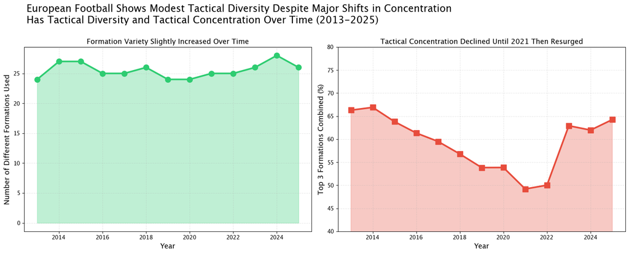

```python
# TACTICAL DIVERSITY ANALYSIS

# Calculate diversity metrics by year
diversity_metrics = []

for year in sorted(df['year'].unique()):
    year_df = df[df['year'] == year]
    year_formations = pd.concat([year_df['home_club_formation'],
                                 year_df['away_club_formation']])

    total = len(year_formations)
    formation_counts = year_formations.value_counts()

    # Simple metrics
    unique_formations = year_formations.nunique()
    top_formation_pct = 100 * formation_counts.iloc[0] / total
    top_3_combined_pct = 100 * formation_counts.head(3).sum() / total

    diversity_metrics.append({
        'year': year,
        'unique_formations': unique_formations,
        'top_formation_pct': top_formation_pct,
        'top_3_combined_pct': top_3_combined_pct
    })

diversity_df = pd.DataFrame(diversity_metrics)

# Create visualization
fig, axes = plt.subplots(1, 2, figsize=(16, 6))

# Plot 1: Number of different formations used
ax1 = axes[0]
ax1.plot(diversity_df['year'], diversity_df['unique_formations'],
         marker='o', linewidth=3, markersize=10, color='#2ecc71')
ax1.set_xlabel('Year', fontsize=13, fontweight='bold')
ax1.set_ylabel('Number of Different Formations Used', fontsize=13, fontweight='bold')
ax1.set_title('Formation Variety Slightly Increased Over Time', fontsize=13, fontweight='bold')
ax1.grid(True, alpha=0.3, linestyle='--')
ax1.fill_between(diversity_df['year'], diversity_df['unique_formations'], alpha=0.3, color='#2ecc71')


# Plot 2: Top 3 formations dominance
ax2 = axes[1]
ax2.plot(diversity_df['year'], diversity_df['top_3_combined_pct'],
         marker='s', linewidth=3, markersize=10, color='#e74c3c')
ax2.set_xlabel('Year', fontsize=13, fontweight='bold')
ax2.set_ylabel('Top 3 Formations Combined (%)', fontsize=13, fontweight='bold')
ax2.set_title('Tactical Concentration Declined Until 2021 Then Resurged', fontsize=13, fontweight='bold')
ax2.grid(True, alpha=0.3, linestyle='--')
ax2.fill_between(diversity_df['year'], diversity_df['top_3_combined_pct'], alpha=0.3, color='#e74c3c')
ax2.set_ylim(40, 80)


# Main title
fig.text(0.045, 0.98, 'European Football Shows Modest Tactical Diversity Despite Major Shifts in Concentration\nHas Tactical Diversity and Tactical Concentration Over Time (2013-2025)',
        fontsize=18, fontweight='bold')

plt.tight_layout()
plt.subplots_adjust(top=0.88)
plt.show()
```

The data reveals a nuanced picture: Formation Variety:

- 2013: 24 different formations used
- 2025: 26 different formations used
- Change: +2 formations (modest increase, not so significant)

Tactical Concentration:

- 2013: Top 3 formations = 66.3% of all games
- 2021: Top 3 formations = 49.4% (peak diversity)
- 2025: Top 3 formations = 64.3% (reconcentration)

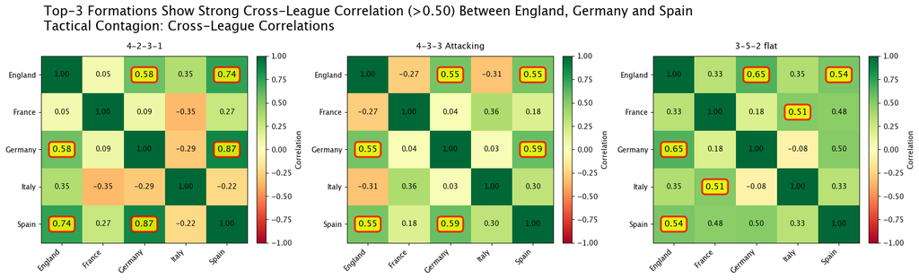

```python
# TACTICAL CONTAGION - CORRELATION HEATMAP

# Analyze correlations for 3 formations
formations_to_analyze = ['4-2-3-1', '4-3-3 Attacking', '3-5-2 flat']

# Create subplots for 3 heatmaps
fig, axes = plt.subplots(1, 3, figsize=(18, 5))

for idx, formation in enumerate(formations_to_analyze):
    ax = axes[idx]

    # Calculate usage by league and year
    league_adoption = []

    for year in sorted(df['year'].unique()):
        for comp_id in ['GB1', 'ES1', 'IT1', 'L1', 'FR1']:
            league_df = df[(df['year'] == year) & (df['competition_id'] == comp_id)]

            if len(league_df) > 0:
                league_formations = pd.concat([league_df['home_club_formation'],
                                              league_df['away_club_formation']])
                total = len(league_formations)

                count = (league_formations == formation).sum()
                percentage = 100 * count / total if total > 0 else 0

                league_name = competitions[competitions['competition_id'] == comp_id]['country_name'].values[0]

                league_adoption.append({
                    'year': year,
                    'league': league_name,
                    'percentage': percentage
                })

    adoption_df = pd.DataFrame(league_adoption)
    adoption_pivot = adoption_df.pivot(index='year', columns='league', values='percentage')

    # Calculate correlation matrix
    corr_matrix = adoption_pivot.corr()

    # Create heatmap with custom colormap
    im = ax.imshow(corr_matrix, cmap='RdYlGn', aspect='auto', vmin=-1, vmax=1)

    # Set ticks and labels
    ax.set_xticks(range(len(corr_matrix.columns)))
    ax.set_yticks(range(len(corr_matrix.columns)))
    ax.set_xticklabels(corr_matrix.columns, rotation=45, ha='right', fontsize=10)
    ax.set_yticklabels(corr_matrix.columns, fontsize=10)

    # Add correlation values as text with emphasis on >0.50
    for i in range(len(corr_matrix)):
        for j in range(len(corr_matrix)):
            value = corr_matrix.iloc[i, j]

            # Emphasize correlations > 0.50 (excluding diagonal)
            if i != j and value > 0.50:
                # Strong correlation - bold, larger font, box
                text = ax.text(j, i, f'{value:.2f}',
                              ha="center", va="center",
                              color="black", fontsize=12, fontweight='bold',
                              bbox=dict(boxstyle='round,pad=0.4',
                                       facecolor='yellow',
                                       edgecolor='red',
                                       linewidth=2.5, alpha=0.8))
            else:
                # Normal correlation
                text = ax.text(j, i, f'{value:.2f}',
                              ha="center", va="center",
                              color="black", fontsize=10, fontweight='normal')

    ax.set_title(f'{formation}', fontsize=12, fontweight='bold', pad=10)

    # Add colorbar
    cbar = plt.colorbar(im, ax=ax, fraction=0.046, pad=0.04)
    cbar.set_label('Correlation', fontsize=10)

# Main title
fig.text(0.05, 0.98, 'Top-3 Formations Show Strong Cross-League Correlation (>0.50) Between England, Germany and Spain \nTactical Contagion: Cross-League Correlations',
        fontsize=18, fontweight='bold')

plt.tight_layout()
plt.subplots_adjust(top=0.88)
plt.savefig('tactical_contagion_heatmap.png', dpi=300, bbox_inches='tight')
plt.show()
```

Correlation analysis reveals which leagues influence each other:

4-2-3-1 (Strong Contagion):

- England ↔ Germany: 0.58 correlation
- England ↔ Spain: 0.74 correlation
- Germany ↔ Spain: 0.87 correlation (very strong)

Interpretation: These leagues adopt 4-2-3-1 in synchronized patterns—when one league increases usage, others follow. This is tactical contagion.

4-3-3 Attacking (Moderate Contagion):

- England ↔ Germany: 0.55 correlation
- England ↔ Spain: 0.55 correlation
- Germany ↔ Spain: 0.59 correlation

Interpretation: Some cross-league influence, but less coordinated than 4-2-3-1.

- Italy ↔ Others: Generally low or negative correlations
- France ↔ Italy: 0.51 correlation (moderate, but Italy-specific)

Interpretation: Italy's 3-5-2 is isolated—it doesn't spread to other leagues, confirming cultural/traditional roots.

##### What This Data Shows:

Successful tactics spread quickly across connected leagues (England, Germany, Spain)

Cultural tactics persist despite external trends (Italy's 3-5-2)